#Assignment #2 #Name: Pradeep KUmar Kankipati #Email ID: pk593@drexel.edu

#A. Data Preparation #A.1. Data Loading and Initial Transformation

Loading data from CSV file and transforming the default.payment.next.month variable into a nominal variable:

```r
library(ggplot2)
cc <- read.csv("UCI_Credit_Card.csv")
cc$default.payment.next.month <- factor(cc$default.payment.next.month,levels=c(0,1), labels=c("No","Yes"))
```

A.2. Demographic Variables

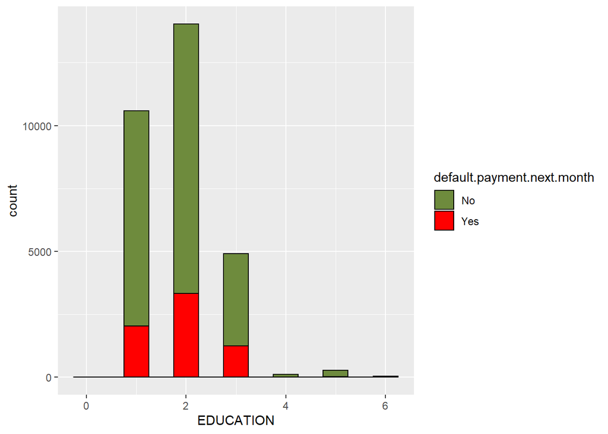

```r
ggplot(cc, aes(x=EDUCATION, fill=default.payment.next.month, color=default.payment.next.month)) +   geom_histogram(binwidth=0.5, position="stack") +
  scale_color_manual(values=c("black","black")) +
  scale_fill_manual(values=c("darkolivegreen4", "red"))
```

From the above plot,It can be observed that better the education the lower possibilty to default. Here we don’t have much data for the 4,5 and 6 values.we have 1-Graduate, 2-University and 3-High School data and graduates have less changes to default than others.

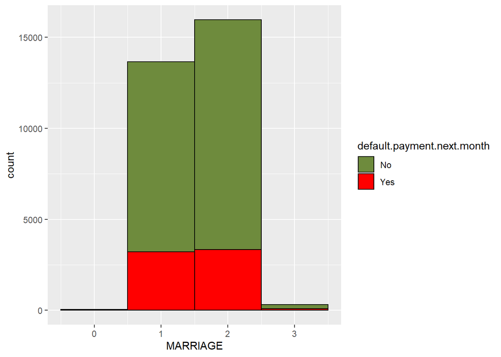

```r
ggplot(cc, aes(x=MARRIAGE, fill=default.payment.next.month, color=default.payment.next.month)) +
  geom_histogram(binwidth=1, position="stack") +
  scale_color_manual(values=c("black","black")) +
  scale_fill_manual(values=c("darkolivegreen4", "red"))
```

From the Plot married person is more likely to get default also our data contain more number of singles than married but the defaulted persons in both the cases are almost same.From this we can observe that married persons has high chance to get default.

#A.3. Payment Status Variables

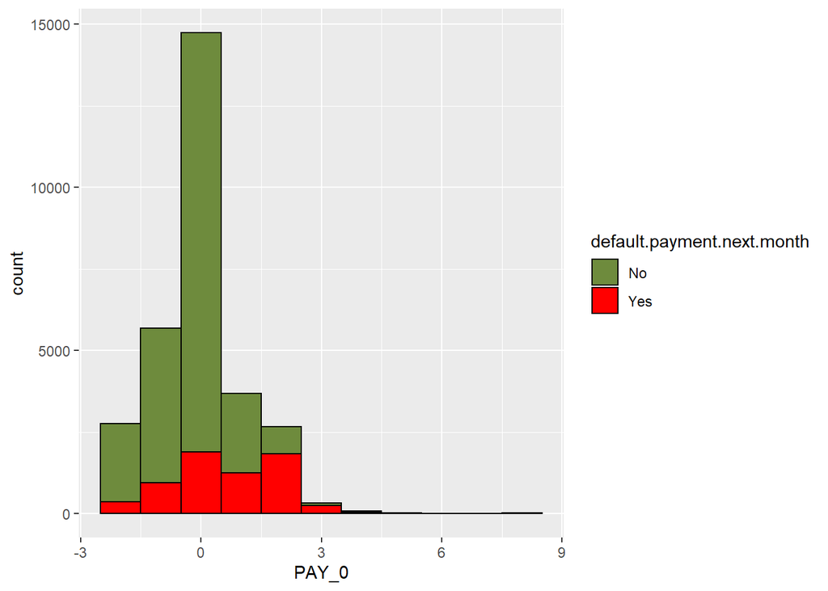

```r
ggplot(cc, aes(x=PAY_0, fill=default.payment.next.month, color=default.payment.next.month)) +
  geom_histogram(binwidth=1, position="stack") +
  scale_color_manual(values=c("black","black")) +
  scale_fill_manual(values=c("darkolivegreen4", "red"))
```

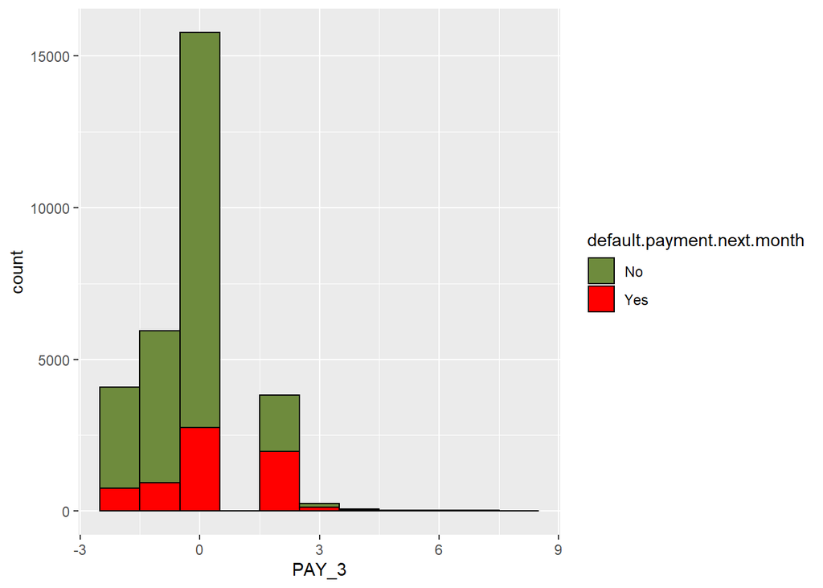

```r
ggplot(cc, aes(x=PAY_3, fill=default.payment.next.month, color=default.payment.next.month)) +
  geom_histogram(binwidth=1, position="stack") +
  scale_color_manual(values=c("black","black")) +
  scale_fill_manual(values=c("darkolivegreen4", "red"))
```

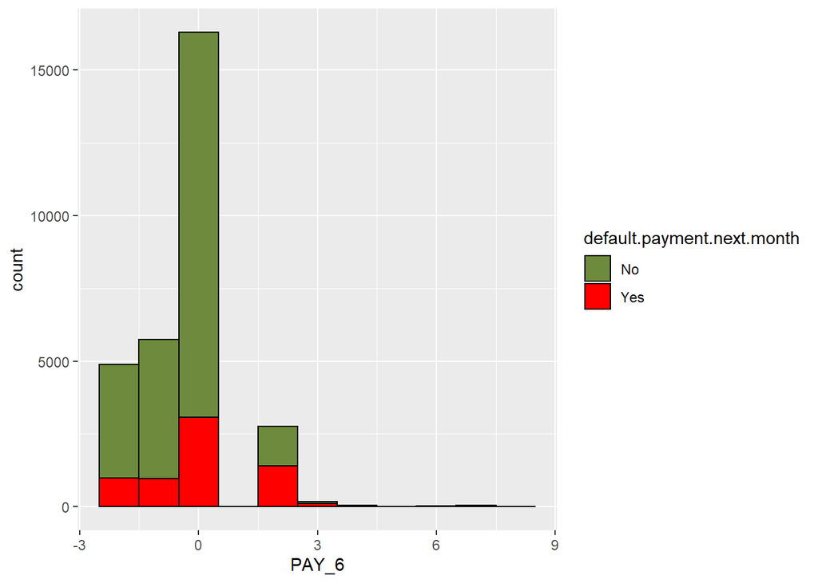

```r
ggplot(cc, aes(x=PAY_6, fill=default.payment.next.month, color=default.payment.next.month)) +
  geom_histogram(binwidth=1, position="stack") +
  scale_color_manual(values=c("black","black")) +
  scale_fill_manual(values=c("darkolivegreen4", "red"))
```

Here I am considering the following repayments: PAY_0: Repayment status in September, 2005 PAY_3: Repayment status in July, 2005 PAY_6: Repayment status in April, 2005

where -1=pay duly, 1=payment delay for one month, 2=payment delay for two months, … , 9=payment delay for nine months and above. It can be observed that the default due to delay raised from month by month from one to three.

#A.4. Transforming Nominal Variables

Transforming related demographic variables into nominal values with labels 1.SEX: Gender (1=male, 2=female) 2.EDUCATION: (1=graduate school, 2=university, 3=high school, 4=others, 5=unknown, 6=unknown) 3.MARRIAGE: Marital status (1=married, 2=single, 3=others)

```r
cc$SEX <- factor(cc$SEX,levels=c(1,2), labels=c("Male", "Female"))
cc$EDUCATION <- factor(cc$EDUCATION,levels=c(1,2,3,4,5,6), labels=c("graduate school","university","high school","others","unknown","unknown"))
cc$MARRIAGE <- factor(cc$MARRIAGE,levels=c(1,2,3), labels=c("married","single","others"))
```

#viewing the transformed variables

```r
View(cc$SEX)
View(cc$EDUCATION)
View(cc$MARRIAGE)
```

#A.5. Selection of Training Data selecting 5000 random rows for training data.

```r
train <- cc[sample(nrow(cc), 5000), ]
```

# Double checking the training data with nrow(train) and/or View(train)

```r
nrow(train)
```

```
## [1] 5000
```

```r
View(train)
```

A.6. Selecting two rows of Testing Data from the data set

```r
test <- cc[c(27,21999),]
test
```

```
##          ID LIMIT_BAL    SEX       EDUCATION MARRIAGE AGE PAY_0 PAY_2
## 27       27     60000   Male graduate school   single  27     1    -2
## 21999 21999    190000 Female      university   single  27     0     0
##       PAY_3 PAY_4 PAY_5 PAY_6 BILL_AMT1 BILL_AMT2 BILL_AMT3 BILL_AMT4
## 27       -1    -1    -1    -1      -109      -425       259       -57
## 21999     0     0     0     0     97136     98767    101452    103471
##       BILL_AMT5 BILL_AMT6 PAY_AMT1 PAY_AMT2 PAY_AMT3 PAY_AMT4 PAY_AMT5
## 27          127      -189        0     1000        0      500        0
## 21999    104083    106359     4418     5452     5471     4083     4359
##       PAY_AMT6 default.payment.next.month
## 27        1000                        Yes
## 21999     3697                         No
```

– B. Data Classification B.1. Naive Bayes using Demographic Variables

Naive Bayes is an algorithm based on conditional probability with an assumption that all the variables are contiditionally independent to each other.

Determining prior probabilities for the data set values.

```r
d_prob <- table(train$default.payment.next.month)
d_prob
```

```
##
##   No  Yes
## 3910 1090
```

```r
d_prob <- d_prob/sum(d_prob)
d_prob
```

```
##
##    No   Yes
## 0.782 0.218
```

Now we are modeling the nomial variables data using the Naive Bayes for which we are loading the e1071.

```r
library(e1071)
nbDem <- naiveBayes(default.payment.next.month ~ SEX + EDUCATION + MARRIAGE, train)
nbDem
```

```
##
## Naive Bayes Classifier for Discrete Predictors
##
## Call:
## naiveBayes.default(x = X, y = Y, laplace = laplace)
##
## A-priori probabilities:
## Y
##    No   Yes
## 0.782 0.218
##
## Conditional probabilities:
##      SEX
## Y          Male    Female
##   No  0.3790281 0.6209719
##   Yes 0.4266055 0.5733945
##
##      EDUCATION
## Y     graduate school   university  high school       others      unknown
##   No     0.3756722151 0.4576184379 0.1487836108 0.0056338028 0.0122919334
##   Yes    0.2889908257 0.5183486239 0.1871559633 0.0009174312 0.0045871560
##
##      MARRIAGE
## Y         married      single      others
##   No  0.443447038 0.546806874 0.009746089
##   Yes 0.483011938 0.500459137 0.016528926
```

```r
predict(nbDem, test[1,])
```

```
## [1] No
## Levels: No Yes
```

```r
predict(nbDem, test[2,])
```

```
## [1] No
## Levels: No Yes
```

Predicted result for the test data 2 is not default which is exactly matches with the original data set.

B.2. Naive Bayes using Payment Status

Building the Naive bayes model using the payment satus variables pay0,pay3 and pay6

```r
nbPay <- naiveBayes(default.payment.next.month ~ PAY_0 + PAY_3 + PAY_6, train)
nbPay
```

```
##
## Naive Bayes Classifier for Discrete Predictors
##
## Call:
## naiveBayes.default(x = X, y = Y, laplace = laplace)
##
## A-priori probabilities:
## Y
##    No   Yes
## 0.782 0.218
##
## Conditional probabilities:
##      PAY_0
## Y           [,1]      [,2]
##   No  -0.2209719 0.9280981
##   Yes  0.6972477 1.3998858
##
##      PAY_3
## Y           [,1]     [,2]
##   No  -0.3153453 1.048843
##   Yes  0.3660550 1.503881
##
##      PAY_6
## Y            [,1]     [,2]
##   No  -0.39667519 1.017091
##   Yes  0.07614679 1.460430
```

```r
predict(nbPay, test[1,])
```

```
## [1] No
## Levels: No Yes
```

```r
predict(nbPay, test[2,])
```

```
## [1] No
## Levels: No Yes
```

Predicted result for the test data 2 is not default which is exactly matches with the original data set.

B.3. Smoothed Naive Bayes using Payment Status

Now we are smoothing the nominal variables with the laplace transform with constant =1.5

```r
nbPay <- naiveBayes(default.payment.next.month ~ PAY_0 + PAY_3 + PAY_6, train, laplace=1.5)
predict(nbPay, test[1,])
```

```
## [1] No
## Levels: No Yes
```

```r
predict(nbPay, test[2,])
```

```
## [1] No
## Levels: No Yes
```

Predicted result for the test data 2 is not default which is exactly matches with the original data set.

C. Classification with Decision Tree C.1. Basic Decision Tree :

For supervised learning tasks the tree based algorithms are considered to be one the best algorithms.Now we are building a decision tree using up to three payment status variables pay0,pay3 and pay6 as predictors

```r
library("rpart")
library("rpart.plot")
dtPay <- rpart(default.payment.next.month ~ PAY_0 + PAY_3 + PAY_6,
            method="class",
            data=train, parms=list(split='information'),
            minsplit=20, cp=0.02)
```

Plotting decision tree using rpart.

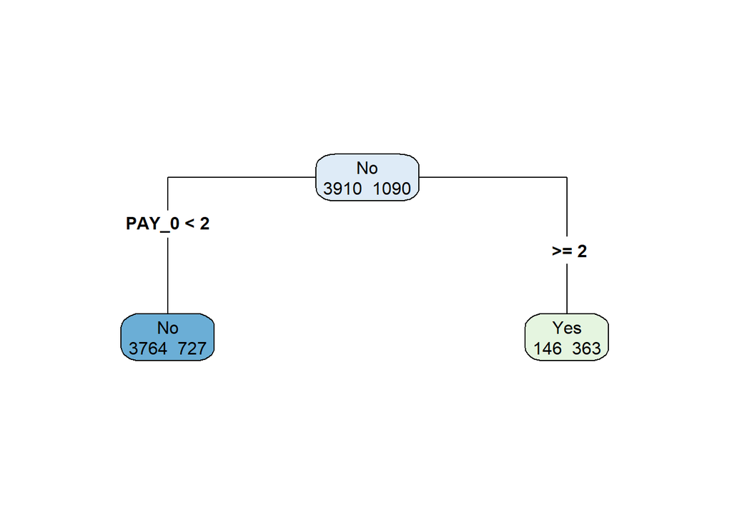

```r
rpart.plot(dtPay, type=4, extra=1)
```

```r
predict(dtPay, test[1,])
```

```
##           No       Yes
## 27 0.8381207 0.1618793
```

```r
predict(dtPay, test[2,])
```

```
##              No       Yes
## 21999 0.8381207 0.1618793
```

C.2. Decision Tree with a Different Complexity Parameter

Rebuild the decision tree with a cp=0.001 for the same variables PAY_0,PAY_3 and PAY_6

```r
dtPay <- rpart(default.payment.next.month ~ PAY_0 + PAY_3 + PAY_6,
            method="class",
            data=train, parms=list(split='information'),
            minsplit=20, cp=0.001)
```

visualizing the decision tree using rpart.plot()

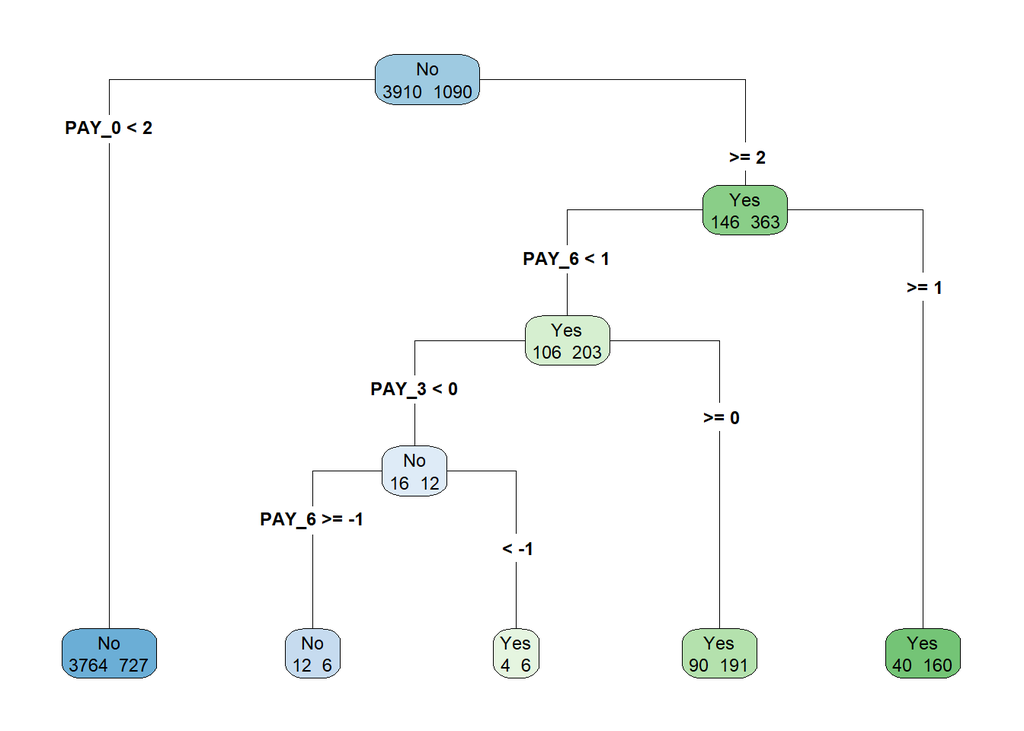

```r
rpart.plot(dtPay, type=4, extra=1)
```

from the plot, as complexity parameter Cp decreases leads to increase in the number of the comparision in the model with more number of nodes.